# customer_time_series_with_covariant

## Import data processed in Python

```r
library(readr)
library(forecast)
combined_clean <- read_csv("C:/Users/wangka3/Desktop/learning/R_exercise2/combined_clean.csv")
```

## The attempt to use ARIMAX

```r
train_data = combined_clean[1:15912, 5:58]
test_data = combined_clean[15913:17376, 5:58]
```

```r
model_cust = auto.arima(combined_clean$cust_168[1:15912],
                        xreg = data.matrix(train_data))
```

```r
model_cust
```

```
Series: combined_clean$cust_168[1:15912]
Regression with ARIMA(0,1,2) errors

Coefficients:
         ma1      ma2  var_w_168  var_w_last_2  var_w_last_4  var_w_last_8  var_w_last_16  var_w_last_32
      0.1548  -0.3857    -0.0055       -0.0071       -0.0041        0.0049        -0.0049          4e-04
s.e.  0.0160   0.0195     0.0015        0.0020        0.0017        0.0013         0.0011          1e-03
      var_w_last_64  var_w_last_128  var_w_last_168  var_t_168  var_t_last_2  var_t_last_4  var_t_last_8
            -0.0037           9e-04          0.0017    -0.9031       -2.9582        1.2101        2.1955
s.e.         0.0009           9e-04          0.0009     0.6483        0.9740        0.7903        0.4681
      var_t_last_16  var_t_last_32  var_t_last_64  var_t_last_128  var_t_last_168  var_at_168  var_at_last_2
            -1.7964         0.8206        -0.2186          0.7133         -0.6609      0.0690         0.1280
s.e.         0.3177         0.2574         0.2317          0.2295          0.2241      0.4175         0.5865
      var_at_last_4  var_at_last_8  var_at_last_16  var_at_last_32  var_at_last_64  var_at_last_128
            -0.3482        -0.6028         -0.0549         -0.0154         -0.2745          -0.4134
s.e.         0.4870         0.3259          0.2435          0.2075          0.1948           0.1934
      var_at_last_168  var_m_168  var_m_last_2  var_m_last_4  var_m_last_8  var_m_last_16  var_m_last_32
               0.6196    -0.0988        0.0196        0.1765       -0.1437         0.1093        -0.0413
s.e.           0.1913     0.1340        0.1786        0.1440        0.0852         0.0552         0.0412
      var_m_last_64  var_m_last_128  var_m_last_168  var_hm_168  var_hm_last_2  var_hm_last_4  var_hm_last_8
             0.0081         -0.0224         -0.0009      0.1741         0.1433        -0.0007        -0.2693
s.e.         0.0352          0.0344          0.0342      0.2710         0.3953         0.3201         0.1900
      var_hm_last_16  var_hm_last_32  var_hm_last_64  var_hm_last_128  var_hm_last_168  var_wd_168
              0.4541         -0.0705          0.4325          -0.2045          -0.0847      0.2152
s.e.          0.1195          0.0865          0.0720           0.0710           0.0691      0.2183
      var_wd_last_2  var_wd_last_4  var_wd_last_8  var_wd_last_16  var_wd_last_32  var_wd_last_64
             0.5201         0.4549        -0.6646          0.1256         -0.1355         -0.0313
s.e.         0.3160         0.2721         0.2001          0.1642          0.1461          0.1387
      var_wd_last_128  var_wd_last_168
              -0.1957           0.2028
s.e.           0.1356           0.1360

sigma^2 estimated as 7027:  log likelihood=-93014.48
AIC=186143   AICc=186143.4   BIC=186580.4
```

```
    Ljung-Box test

data:  Residuals from Regression with ARIMA(0,1,2) errors
Q* = 21862, df = 3, p-value < 2.2e-16

Model df: 56.   Total lags used: 59
```

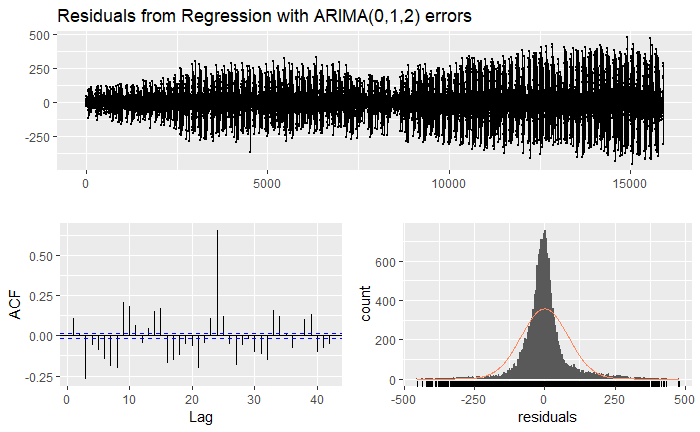

```r
checkresiduals(model_cust)
```

### Seasonality is not reflected

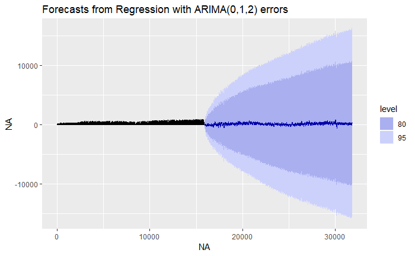

```r
forecast_cust = forecast(model_cust, xreg = data.matrix(train_data))
(autoplot(forecast_cust))
```

## Now use tbats on msts

### With seasonal periods equals to 24 hours and 24 * 7 = 168 hours.

- 15841 is the last row that represents part of some coherent time series data for “cust” and “others” columns. The data used for training ends here.
- 15913 is the first row of the test dataset.
- 17376 is the last row of the combined train-test dataset.

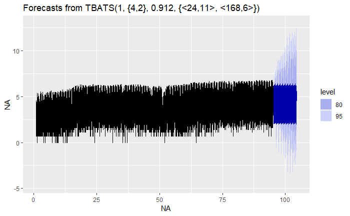

```r
cust <- msts(log(combined_clean$cust_168[1:15841] + 1), seasonal.periods=c(24,168))
model_cust <- tbats(cust)
(autoplot(forecast(model_cust, h = 17376 - 15841)))
```

[figure not shown]

## Try tbats on msts with covariates in xreg

```r
train_data = combined_clean[1:15841, 5:58]
test_data = combined_clean[15842:17376, 5:58]
```

Later I realised that the tbats model is based on ets which will not take advantage of the covariates. https://robjhyndman.com/hyndsight/tbats-with-regressors/

```r
cust <- msts(log(combined_clean$cust_168[1:15841] + 1), seasonal.periods=c(24,168))
model_cust_improved <- tbats(cust, xreg = data.matrix(train_data))
```

```r
pred_others = forecast(model_others, h = 17376 - 15841)
result_others = exp(pred_others$mean) - 1
result_others = result_others[(15913 - 15841) : (17376 - 15841)]
```